# 5. Stochastic Methods

2023-08-14

## Random variables

- Life is filled with heterogeneity and uncertainty.
- Our model also must account for this.
  - Agents of different types distributed in some way.
  - Agents are hit with shocks that affect decisions and outcomes.
- We often want to calculate statistics that depend on this randomness:
  - Expected Continutation Values.
  - Probability of making a given decision.
- Problem:
  1. Distributions often don’t have simple closed form solutions.
  2. Calculations of these statistics can be challenging.

## Solution

- Let our computers calculate numeric approximations of these values.
- We can do this by performing simulations from the known random distribution.

## Example - Birthday Problem

- Question: If there are N people in a room, what is the probability that at least two of them share the same birthday?
  - Assume all days are equally likely.
  - Ignore leap years.
- Closed form expression exists, but is a messy combination of binomials.
- Can perform simulations to arrive at a good approximation.

## Example - Distance of Points in a Cube

- Question: If two points are chosen at random within the uniform cube, what is the average distance between them?
- Close form solution is an integral in six dimensions: \[ \tiny E[D] = \int_0^1\int_0^1\int_0^1\int_0^1\int_0^1\int_0^1\sqrt{(x_1-y_1)^2+(x_2-y_2)^2+(x_3-y_3)^2)}dx_1dx_2dx_3dy_1dy_2dy_3 \]
- Much quicker to perform some simulations to get a good approximation.

## Economic Example: College Choice

- In period 1, individual chooses to go to college based on expected value: \[ V_1 = \max_{s \in \{0,1\}} \textbf{E}_\epsilon[V_2(s,\epsilon)] \] In period 2, agent chooses whether to supply labor: \[ V_2(s) = \max_{s \in \{0,1\}} \log(c) + \alpha (1-\ell) \] \[ c = \begin{cases} B, \:\:\: \ell = 0 \\ \exp(\beta_0 + \beta_1 s + \epsilon), \:\:\: \ell = 1 \end{cases} \] \[ \epsilon \sim N(0,\sigma) \]

## Why is this hard?

- We need to know the expected continuation value: \[ V_1 = \max_{s \in \{0,1\}} \textbf{E}_\epsilon[V_2(s,\epsilon)] \]
- Shock \(\epsilon\) will effect our wage and whether we decide to work our not.
  - If \(\epsilon\) is low, we will decide not to work.
- Need to solve for the cut-off value \(\epsilon\) for each schooling decision, and then take a conditional expectation.
- Or we can just ask our computer to do some simulations to approximate the expectation.

## Non-random sequences

- Simulating random numbers can be a good way to approximate expectations.
- But requires a large number of simulations to obtain good coverage of the distribution.
- Non-random sequences can obtain better coverage of the distribution.
- Ex: Halton sequence with base 2:
  - 1/2, 1/4, 3/4, 1/8, 5/8, 3/8, 7/8, 1/16, 9/16, …
- Ex: Halton sequence with base 3:
  - 1/3, 2/3, 1/9, 4/9, 7/9, 2/9, 5/9, 8/9, 1/27, …
- The Halton sequence will appear to be random for many purposes.

## Simulating from Uniform Square

- Consider drawing random numbers \((x,y)\) where both are i.i.d. uniformly distributed.
- Random Numbers (left) and Halton Sequences (Right)

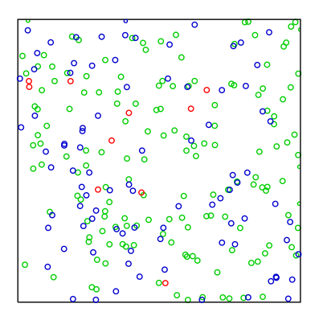

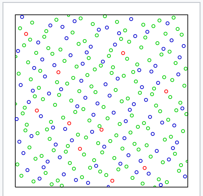

https://en.wikipedia.org/wiki/Halton_sequence

## Quadrature: Approximating Integrals

- We are interested in approximating an integral (such as an expectation):

\[ \int_a^b g(x)dx. \] - To do this, we choose a set of n nodes (\(x_i\)) and weights (\(w_i\)) and calculate: \[ \sum_i^n w_i g(x_i) \approx \int_a^b g(x)dx. \] - How do we best choose the weights and nodes? Ask Gauss

## Quadrature Examples

- Choice of \((w_i, x_i)\) depends on the integral:
  - https://en.wikipedia.org/wiki/Gaussian_quadrature#Other_forms
- Gauss-Legendre Quadrature: \[ \int_{-1}^1 g(x) dx. \]
- Gauss-Hermite Quadrature: Good for normal distribution. \[ \int_{-\infty}^\infty f(x) \exp(-x^2) dx. \]
- FastGaussQuadrature.jl provides nodes and weights.